# Stat 360 Topic Modeling

Meredith Brown and Caleb Kornfein

2020-04-30

## Loading Packages

```r
library(tidyverse)
library(tm)
library(stringr)
library(stringi)
library(wordcloud)
library(topicmodels)
library(ldatuning)
library(usethis)
library(LDAvis)
library(servr)
library(lda)
library(gistr)
library(reshape2)
```

## Loading Data

```r
debates <- read_csv("debate_transcripts_v3_2020-02-26.csv")
```

## Cleaning Data

```r
# Set global seed
set.seed(1)

# Here we drop all the columns except speaker and speech

keeps <- c("speaker", "speech")
debates <- debates[, keeps, drop = FALSE]

# A list of all the democratic candidates that appeared in any of the debates -- searched online

demCandidates <- c("Michael Bennet", "Joe Biden", "Cory Booker", "Pete Buttigieg", "Julian Castro", "Bill de Blasio", "John Delaney", "Tulsi Gabbard", "Kirsten Gillibrand", "Kamala Harris", "Jay Inslee", "Amy Klobuchar", "Beto O'Rourke", "Tim Ryan", "Bernie Sanders", "Eric Swalwell", "Elizabeth Warren", "Marianne Williamson", "Andrew Yang", "Michael Bloomberg")

# Filtering the rows out that are not spoken by one of the democratic candidates. Also lol it took me like half an hour to figure out how to include Beto since he had a special symbol in his name

debates <- subset(debates, speaker %in% demCandidates)

# Double checking we got everyone
length(demCandidates)
```

```
## [1] 20
```

```r
length(unique(debates$speaker))
```

```
## [1] 20
```

```r
# Collapsing the speech text by speaker, such that each candidates total responses from all of the debates forms a document

debates <- aggregate(speech ~ speaker, data = debates, FUN = paste, collapse = " ")

## Next we remove punctuation from the speeches

debates$speech <- removePunctuation(debates$speech)
```

## Start using the tm package here for some fancy shenanigans

```r
# definining a "corpus" from the dataframe
debates_source <- VectorSource(debates$speech)
debates_corpus <- VCorpus(debates_source)

# stripping whitespace
debates_corpus <- tm_map(debates_corpus, stripWhitespace)

# converting to all lower case
debates_corpus <- tm_map(debates_corpus, content_transformer(tolower))

# removing common stopwords aka words such as 'a', 'the', 'also'
debates_corpus <- tm_map(debates_corpus, removeWords, stopwords("english"))

# removing numbers
debates_corpus <- tm_map(debates_corpus, removeNumbers)

# removing punctuation
debates_corpus <- tm_map(debates_corpus, removePunctuation)

#removing other uninformative words that came up

Stopwords <- c("can", "actually", "weve", "also", "whats", "youre", "think", "tell", "yes", "want", "well", "bit", "get", "thats", "theyre", "thing", "ive", "able", "like", "lets", "lot", "let", "one", "will", "got", "dont", "said", "put", "done", "going", "around", "part", "two", "good", "act", "say", "sure", "things", "make", "theres", "way", "say", "take", "talk", "something", "many", "new", "people", "see", "just", "need", "now", "away", "even", "much", "really", "cant", "day", "number", "look", "matter", "clear", "understand", "know")

debates_corpus <- tm_map(debates_corpus, removeWords, Stopwords)
```

## Moving on to creating matrices of data

```r
#created a matrix with speaker aka document as the rows (1 - 20) and word as column, with first column being the most frequent word used in the total documents. A ij of the matrix represents that the word in the column index was spoken j times by the ith candidate

dtm <- DocumentTermMatrix(debates_corpus)
rownames(dtm) <- debates$speaker
inspect(dtm)
```

```
## <<DocumentTermMatrix (documents: 20, terms: 8070)>>
## Non-/sparse entries: 25618/135782
## Sparsity           : 84%
## Maximal term length: 20
## Weighting          : term frequency (tf)
## Sample             :
##                   Terms
## Docs               america american country every healthcare president right
##   Amy Klobuchar         39       17      57    50         14       119    67
##   Andrew Yang           10       44      43    21          9        32    37
##   Bernie Sanders        60       85     137    45         91        59    87
##   Beto O'Rourke         22       11      66    18         13        24    22
##   Cory Booker           29       31      55    21         10        56    44
##   Elizabeth Warren      93       29      84    82         54        60    60
##   Joe Biden             45       36      42    43          9       110    51
##   Kamala Harris         43       29      26     9         27        48    16
##   Pete Buttigieg        23       83      79    31         21       130    90
##   Tulsi Gabbard          0       21      37    17          8        29    10
##                   Terms
## Docs               states time trump
##   Amy Klobuchar        25   42    53
##   Andrew Yang           6   12    32
##   Bernie Sanders       30   33    66
##   Beto O'Rourke        12    7    12
##   Cory Booker          31   19    22
##   Elizabeth Warren     38   55    38
##   Joe Biden            68   73    36
##   Kamala Harris        48   20    35
##   Pete Buttigieg       23   42    47
##   Tulsi Gabbard         1    1    16
```

```r
# list of words spoken by candidates at least 100 total times during the debate

findFreqTerms(dtm, 100)
```

```
##   [1] "agree"       "america"     "american"    "americans"   "back"
##   [6] "beat"        "believe"     "better"      "big"         "bill"
##  [11] "billion"     "black"       "bring"       "build"       "campaign"
##  [16] "care"        "change"      "children"    "city"        "climate"
##  [21] "come"        "communities" "community"   "companies"   "congress"
##  [26] "cost"        "country"     "crosstalk"   "deal"        "democratic"
##  [31] "democrats"   "didnt"       "doesnt"      "dollars"     "donald"
##  [36] "economy"     "election"    "end"         "every"       "everybody"
##  [41] "everyone"    "fact"        "families"    "family"      "fight"
##  [46] "first"       "getting"     "give"        "government"  "great"
##  [51] "gun"         "health"      "healthcare"  "help"        "hes"
##  [56] "home"        "house"       "important"   "insurance"   "issue"
##  [61] "job"         "jobs"        "justice"     "keep"        "kids"
##  [66] "last"        "law"         "made"        "making"      "mayor"
##  [71] "means"       "medicare"    "million"     "money"       "must"
##  [76] "never"       "party"       "pay"         "place"       "plan"
##  [81] "point"       "policy"      "president"   "problem"     "public"
##  [86] "question"    "real"        "right"       "running"     "saying"
##  [91] "school"      "senate"      "senator"     "single"      "someone"
##  [96] "stage"       "stand"       "start"       "state"       "states"
## [101] "support"     "system"      "talking"     "tax"         "thank"
## [106] "three"       "time"        "today"       "together"    "trade"
## [111] "trump"       "united"      "vote"        "war"         "washington"
## [116] "whether"     "white"       "win"         "women"       "work"
## [121] "workers"     "working"     "world"       "year"        "years"
```

## Visualizing data as wordclouds

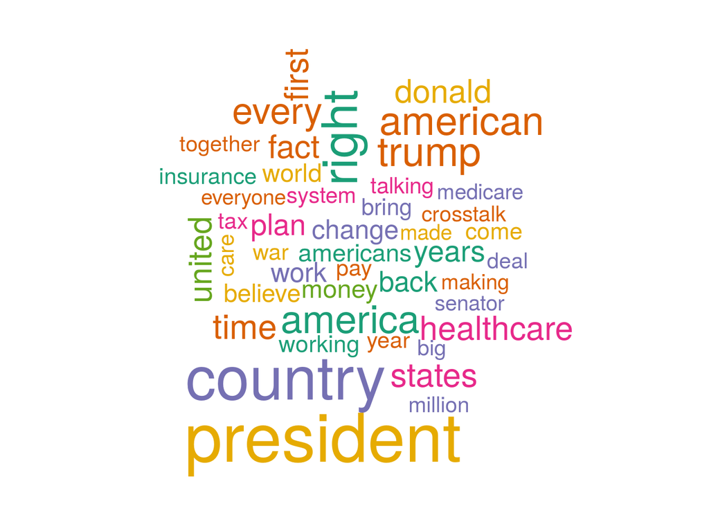

```r
# wordcloud of all the candidates together

freq <- colSums(as.matrix(dtm))
wordcloud(names(freq), freq, min.freq=175, colors=brewer.pal(6, "Dark2"), random.color = TRUE)
```

## Finding Optimal Number of Topics

This function comes from the `ldatuning` package. This function “calculates different metrics to estimate the most preferable number of topics for LDA model” [https://cran.r-project.org/web/packages/ldatuning/ldatuning.pdf]. Here, it uses 4 scoring algorithsm to evaluate the number of topics: Arun 2010, CaoJuan 2009, Griffiths 2004, and Deveaud 2014.

```r
N <- 1000 ; ALPHA <- .01 ; BURNIN = 0;

topicStats <- FindTopicsNumber(dtm
                , topics = seq(3, 35, by = 2)
                , metrics = c("Arun2010", "CaoJuan2009", "Griffiths2004", "Deveaud2014")
                , method = "Gibbs"
                , control = list(alpha = ALPHA   #inputting alpha hyperparameter for topics over documents
                , seed = 1                       #setting seed to 1
                , delta = .01                    #setting delta hyperparameter for words over topics
                , iter = N                       #number of trials equal to N
                , burnin = BURNIN)
                , mc.cores = 4L)                 #adding burn in period
```

This function takes the output from the previous function, a number of topics and the corresponding value from the given metric, and plots the change in values over the number of topics for each metric:

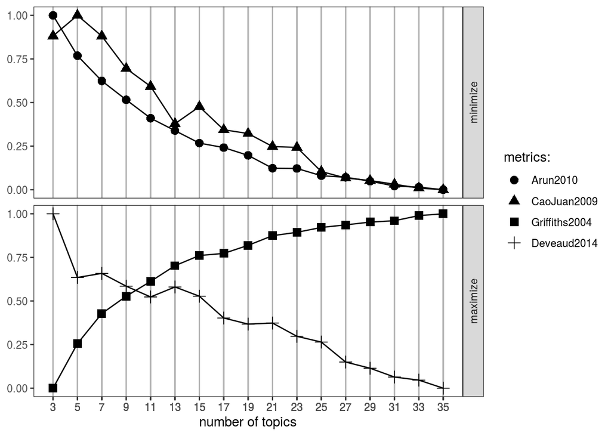

```r
FindTopicsNumber_plot(topicStats)
```

## LDA Model

This LDA function is from the `topicmodels` package. It “estimate[s] a LDA model using for example…Gibbs Sampling” [https://cran.r-project.org/web/packages/topicmodels/topicmodels.pdf]. This will return an object of class LDA, on which we can perform analysis.

```r
K <- 11 ; S <- 10000;

lda <- LDA(dtm                              #inputting our document-term-matrix
           , method = "Gibbs"               #we will be using Gibbs sampling
           , control = list(alpha = ALPHA   #inputting alpha hyperparameter
           , seed = 1                       #setting seed to 1
           , delta = .01                    #setting delta hyperparameter
           , iter = S                       #number of trials equal to S
           , burnin = BURNIN)               #adding burn in period
           , k = K)                         #fixing the number of topics
```

```r
topics(lda, k = 20)
```

```
##       Amy Klobuchar Andrew Yang Bernie Sanders Beto O'Rourke Bill de Blasio
##  [1,]             9           1              8             6              5
##  [2,]            10           2              5             5              2
##  [3,]             2           5             10             2             11
##  [4,]             5          10              2            10             10
##  [5,]             4           8              4            11              3
##  [6,]             7           7              7             1              8
##  [7,]             1           4             11             8              7
##  [8,]             3           3              1             3              1
##  [9,]             8           6              3             4              6
## [10,]             6           9              6             7              4
## [11,]            11          11              9             9              9
##       Cory Booker Elizabeth Warren Eric Swalwell Jay Inslee Joe Biden
##  [1,]          11                7             2         10         4
##  [2,]           2                5            10          5         2
```

[output cut: 45 more lines]

```r
terms(lda, k = 20)
```

```
##       Topic 1       Topic 2     Topic 3       Topic 4          Topic 5
##  [1,] "americans"   "president" "washington"  "fact"           "country"
##  [2,] "country"     "right"     "american"    "deal"           "healthcare"
##  [3,] "communities" "time"      "politics"    "states"         "america"
##  [4,] "american"    "back"      "experience"  "man"            "believe"
##  [5,] "right"       "years"     "president"   "hes"            "working"
##  [6,] "jobs"        "come"      "somebody"    "united"         "insurance"
##  [7,] "problems"    "making"    "generation"  "ever"           "trump"
##  [8,] "money"       "stage"     "whether"     "cost"           "every"
##  [9,] "donald"      "senator"   "policies"    "heres"          "crosstalk"
## [10,] "economy"     "plan"      "ready"       "china"          "care"
## [11,] "business"    "made"      "seen"        "guy"            "united"
## [12,] "home"        "problem"   "climate"     "middle"         "american"
## [13,] "immigrants"  "first"     "order"       "troops"         "question"
## [14,] "kids"        "change"    "political"   "entire"         "health"
```

[output cut: 48 more lines]

After running producting the lda model above, the posterior function helps to evaluate the posterior probabilities of the specific terms per each topic and the specific topics per document.

```r
beta <- posterior(lda)$terms # beta is the terms per topic
theta <- posterior(lda)$topics
theta
```

```
##                                1          2            3          4          5
## Amy Klobuchar       2.448733e-02 0.19275720 2.251451e-02 0.04421552 0.14448115
## Andrew Yang         3.861920e-01 0.13601267 3.450142e-02 0.03772793 0.11293065
## Bernie Sanders      2.039565e-02 0.09281272 1.188883e-02 0.05027860 0.24800771
## Beto O'Rourke       4.698540e-02 0.14246570 4.122627e-02 0.03577025 0.18702317
## Bill de Blasio      2.911541e-02 0.19262741 7.791218e-02 0.02312282 0.34929073
## Cory Booker         9.320120e-02 0.19788119 5.560646e-02 0.03849747 0.14903053
## Elizabeth Warren    3.532751e-02 0.20927326 1.781352e-02 0.02686905 0.21594052
## Eric Swalwell       9.821189e-02 0.21424534 1.755675e-01 0.02383148 0.16069144
## Jay Inslee          1.436555e-05 0.12786772 6.753243e-02 0.05603999 0.22986310
## Joe Biden           2.180393e-02 0.23796738 1.424165e-02 0.30936712 0.12021182
## John Delaney        1.619470e-01 0.16366067 8.568173e-06 0.01885855 0.43355811
## Julian Castro       6.909648e-02 0.19723128 4.104082e-02 0.03810963 0.16917562
## Kamala Harris       3.064410e-02 0.13285968 3.613218e-02 0.04230628 0.19391463
## Kirsten Gillibrand  7.240378e-02 0.15842638 2.811491e-02 0.06729352 0.18482936
## Marianne Williamson 7.746628e-02 0.13983362 2.102484e-01 0.06438925 0.18711209
## Michael Bennet      5.834724e-02 0.18668549 9.801542e-02 0.12951663 0.20535287
## Michael Bloomberg   6.346458e-02 0.42141937 2.957902e-02 0.08749253 0.08502813
## Pete Buttigieg      5.527261e-02 0.23992751 2.352435e-01 0.04933950 0.13167435
## Tim Ryan            1.677616e-01 0.20246920 4.876416e-02 0.12479031 0.20577468
## Tulsi Gabbard       5.248567e-02 0.10416608 6.810998e-02 0.03205388 0.11418167
##                                6            7          8            9
## Amy Klobuchar       2.123798e-02 3.910940e-02 0.02251451 2.437024e-01
## Andrew Yang         3.400503e-02 5.435692e-02 0.06974493 2.035437e-02
## Bernie Sanders      1.112540e-02 3.032028e-02 0.39785868 1.025290e-02
## Beto O'Rourke       2.900813e-01 2.910179e-02 0.04698540 2.607067e-02
## Bill de Blasio      2.569107e-02 6.079051e-02 0.06335876 1.284982e-02
## Cory Booker         3.984818e-02 2.138848e-02 0.05110409 3.151881e-02
## Elizabeth Warren    2.637149e-02 3.314731e-01 0.02885927 8.359944e-03
## Eric Swalwell       2.975216e-05 9.523668e-02 0.04465800 2.975216e-05
## Jay Inslee          9.195386e-02 1.868957e-02 0.06034966 3.161857e-02
## Joe Biden           2.337531e-02 1.954506e-02 0.05264233 2.268783e-02
## John Delaney        1.714491e-02 2.057218e-02 0.01371764 7.969257e-02
## Julian Castro       4.145956e-02 1.549761e-02 0.03685341 4.187412e-06
## Kamala Harris       6.014255e-02 2.195463e-02 0.02401266 1.349383e-02
## Kirsten Gillibrand  2.470808e-02 7.836574e-02 0.03152175 8.517090e-06
## Marianne Williamson 1.005925e-05 8.148998e-02 0.07344258 1.005925e-05
## Michael Bennet      3.617972e-02 1.166711e-05 0.04317999 1.166711e-05
## Michael Bloomberg   3.574003e-02 5.915188e-02 0.03450783 2.095360e-02
## Pete Buttigieg      7.026150e-02 4.580045e-02 0.04174096 2.748069e-02
```

[output cut: 8 more lines]

```
## Cory Booker         0.12359217 1.983314e-01
## Elizabeth Warren    0.07174864 2.796367e-02
## Eric Swalwell       0.18746839 2.975216e-05
## Jay Inslee          0.25859419 5.747655e-02
## Joe Biden           0.12109573 5.706185e-02
## John Delaney        0.05912896 3.171081e-02
## Julian Castro       0.19388135 1.976500e-01
## Kamala Harris       0.16441617 2.801233e-01
## Kirsten Gillibrand  0.22571139 1.286166e-01
## Marianne Williamson 0.11267365 5.332408e-02
## Michael Bennet      0.21351985 2.917945e-02
## Michael Bloomberg   0.14663824 1.602479e-02
## Pete Buttigieg      0.06953288 3.372606e-02
## Tim Ryan            0.07190255 6.198610e-02
## Tulsi Gabbard       0.14583091 2.203829e-02
```

## Visualized topics and terms

Next, we can assign pseudo-names for each topic by concatenating the 4 terms with the highest probability from each topic.

```r
pseudo_name <- terms(lda, 4)
topicNames <- apply(pseudo_name, 2, paste, collapse="-")
topicNames
```

```
##                                   Topic 1
##  "americans-country-communities-american"
##                                   Topic 2
##               "president-right-time-back"
##                                   Topic 3
## "washington-american-politics-experience"
##                                   Topic 4
##                    "fact-deal-states-man"
##                                   Topic 5
##      "country-healthcare-america-believe"
##                                   Topic 6
##                   "country-war-lives-end"
##                                   Topic 7
##                "fight-money-big-families"
##                                   Topic 8
##        "country-right-american-companies"
##                                   Topic 9
##             "bring-someone-bill-everyone"
##                                  Topic 10
##            "president-donald-trump-first"
##                                  Topic 11
##              "justice-nation-states-plan"
```

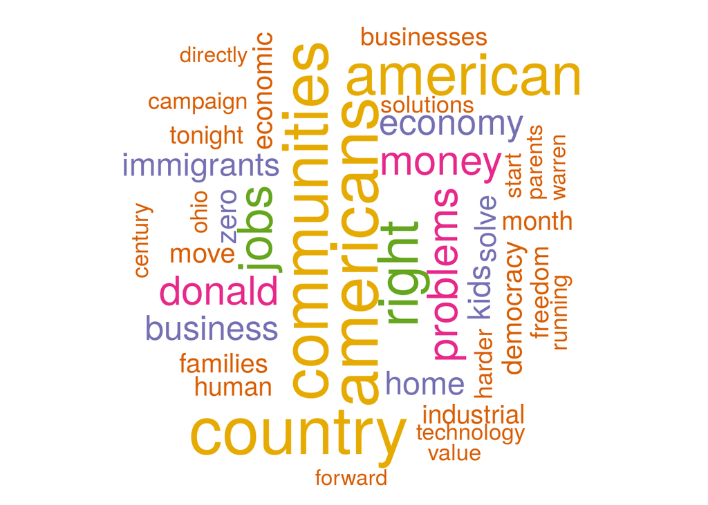

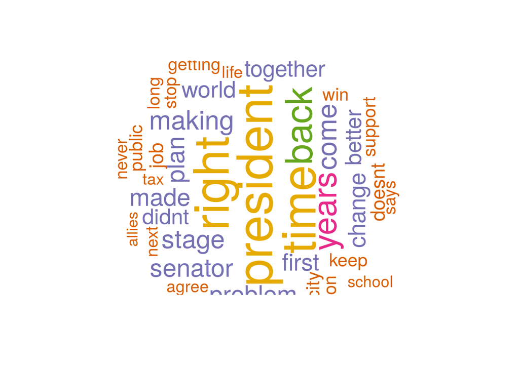

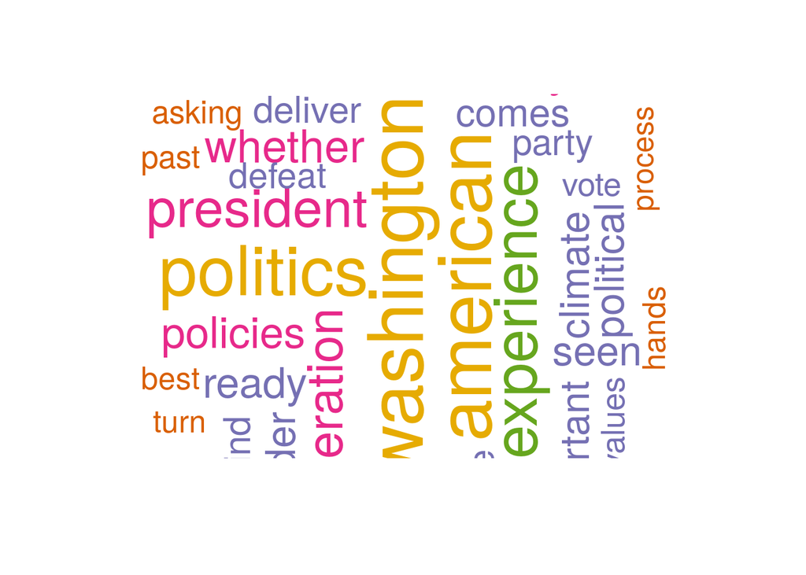

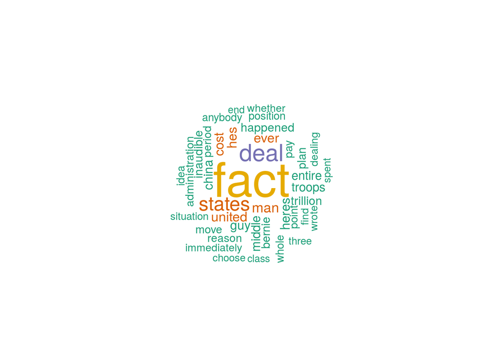

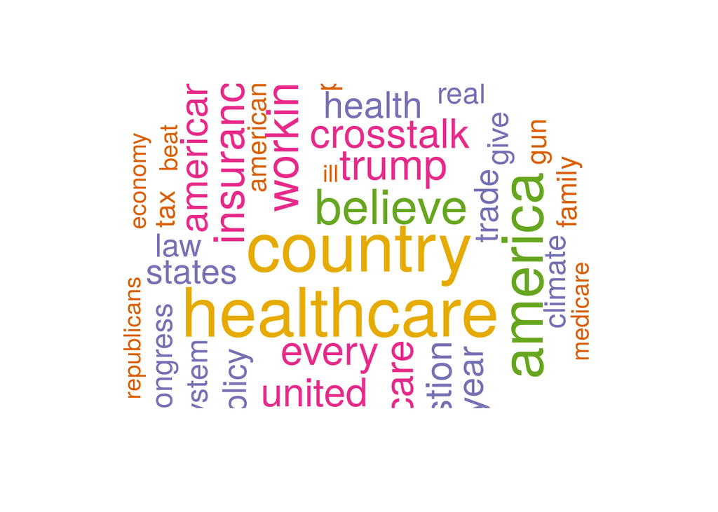

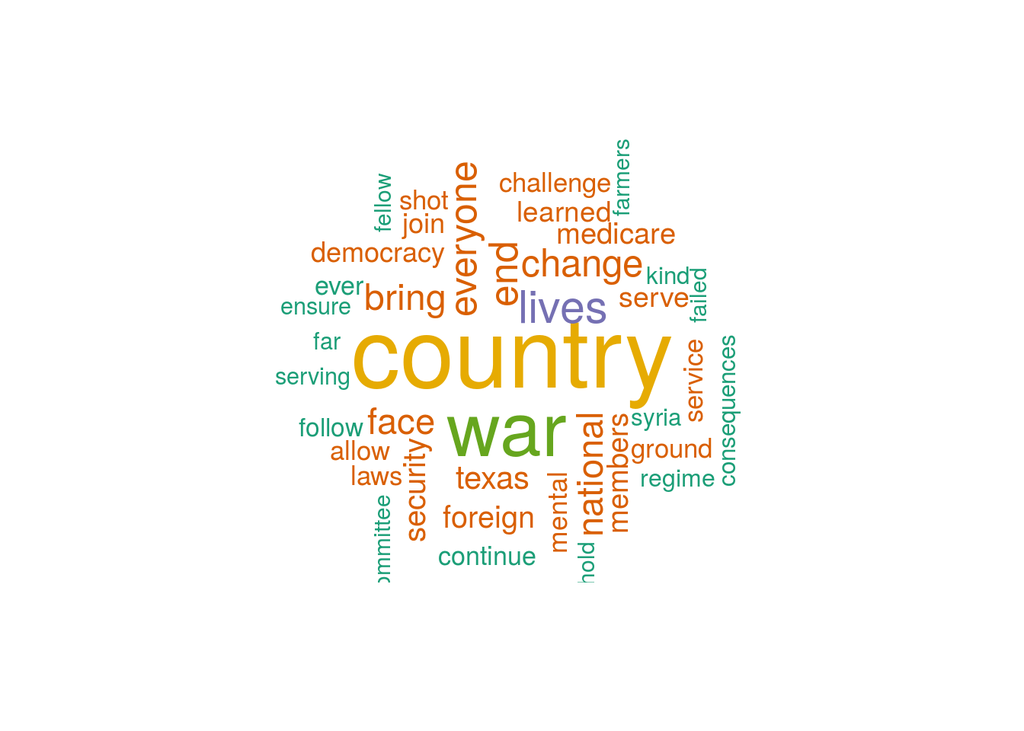

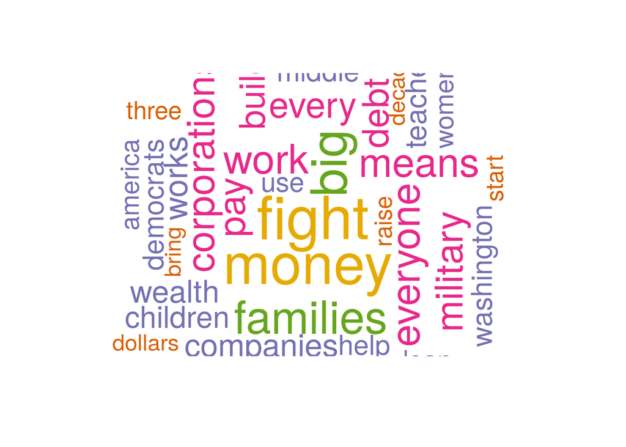

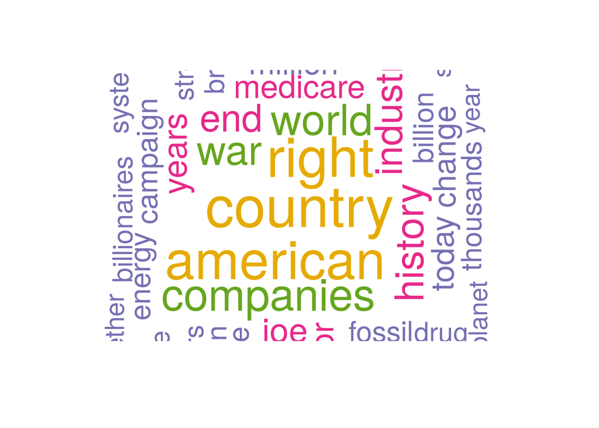

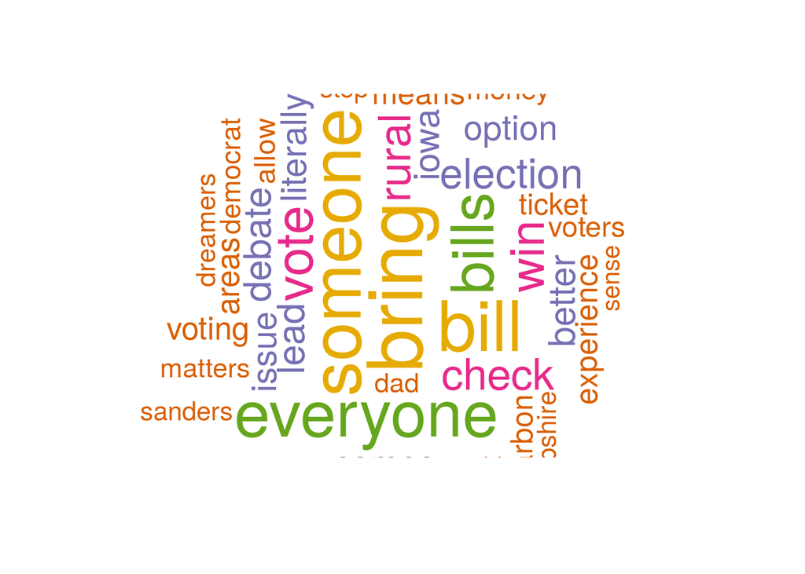

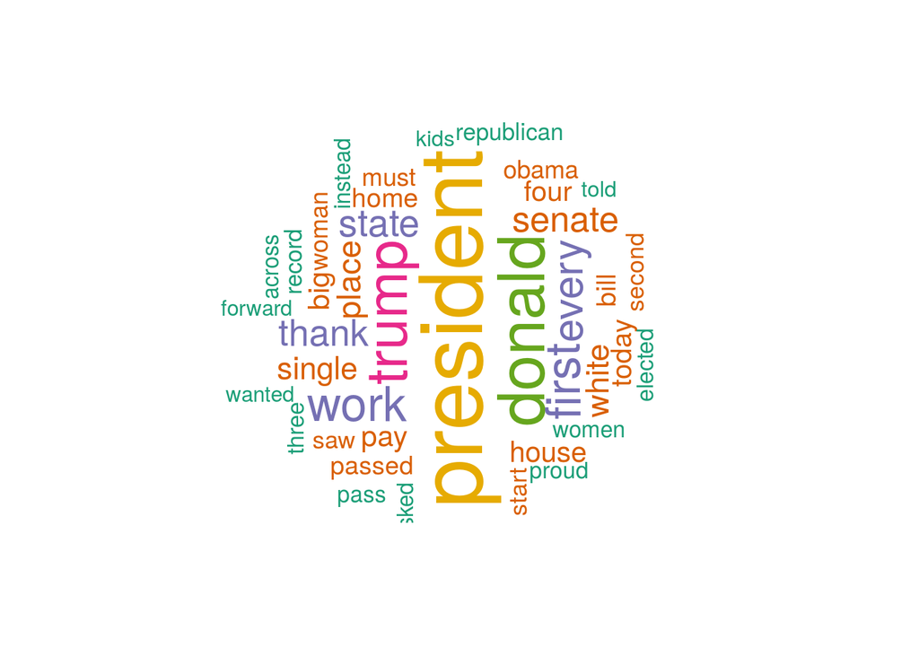

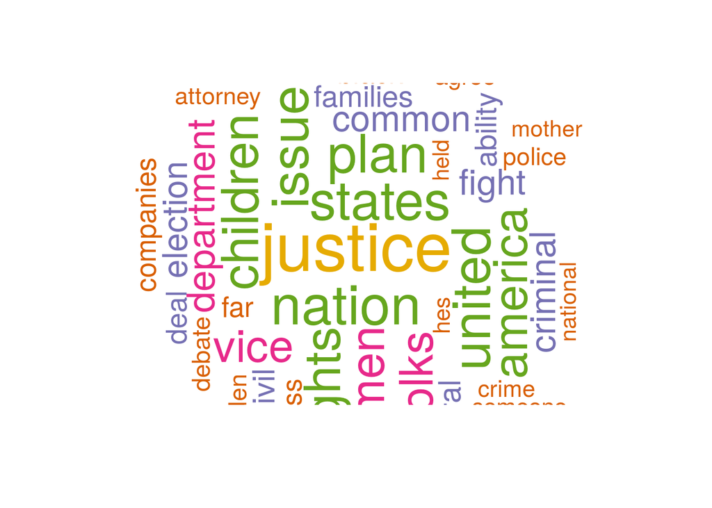

```r
for(i in 1:K){
    topic <- i
    top40terms <- sort(beta[topic,], decreasing=TRUE)[1:40]
    words <- names(top40terms)
    probabilities <- sort(beta[topic,], decreasing=TRUE)[1:40]

    wordcloud(words, probabilities, random.order = FALSE, scale=c(4,.5), rot.per=.5,
              colors = brewer.pal(6, "Dark2"), random.color = FALSE)
}
```

## Re-ranking Topics

As referenced in [https://tm4ss.github.io/docs/Tutorial_6_Topic_Models.html], TF-IDF, otherwise known as Term Frequency - Inverse Document Frequency, calculates “the frequency of a term adjusted for how rarely it is used” [https://www.tidytextmining.com/tfidf.html]. In this way, some of the terms that are used across multiple topics drop in significance to bring attention to the terms that are rarely used and are thus more significant to defining a topic.

```r
# re-rank top topic terms for topic names
topicNames <- apply(lda::top.topic.words(beta, 5, by.score = T), 2, paste, collapse = " ")

# Most probable topics across the corpus, sorted in descending order
topicProportions <- colSums(theta) / nrow(dtm)  # mean probablities over all paragraphs
names(topicProportions) <- topicNames           # assign the topic names created before
sort(topicProportions, decreasing = TRUE)       # show summed proportions (descending)
```

```
##       healthcare country believe america working
##                                       0.19140362
##                  time president right back years
##                                       0.18452949
##                president donald trump first work
##                                       0.13950465
##     communities americans country right american
##                                       0.07823120
##             justice nation rights children folks
##                                       0.06883148
## washington politics american experience somebody
##                                       0.06570308
##                        fact deal states man ever
##                                       0.06499352
##             right country american history world
##                                       0.06182110
##                       country war lives face end
##                                       0.06099040
##            fight big money families corporations
##                                       0.05497083
##                bill someone bills bring everyone
##                                       0.02902063
```

```r
top_per_doc <- topics(lda, k = 20)
data <- melt(top_per_doc)
data <- data %>%
    group_by(Var2) %>%
    mutate(value = value/sum(value))

mycolors <- colorRampPalette(brewer.pal(8, "Set2"))(K)

glimpse(data)
```

```
## Rows: 220
## Columns: 3
## Groups: Var2 [20]
## $ Var1  <int> 1, 2, 3, 4, 5, 6, 7, 8, 9, 10, 11, 1, 2, 3, 4, 5, 6, 7, 8, 9, 1…
## $ Var2  <fct> Amy Klobuchar, Amy Klobuchar, Amy Klobuchar, Amy Klobuchar, Amy…
## $ value <dbl> 0.13636364, 0.15151515, 0.03030303, 0.07575758, 0.06060606, 0.1…
```

[figure not shown]

```r
ggplot(data, mapping=aes(x=Var2, y=value, fill= as.factor(Var1))) +
    geom_bar(stat="identity") +
    labs(y = "Proportion", x = "Candidate", fill = "Topic",
         title = "Per Candidate Proportion of Topics") +
    scale_fill_manual(values = mycolors) +
    theme(axis.text.x = element_text(angle = 90, hjust = 1))
```

## Visualize fitted model with LDAvis

Function from [https://gist.github.com/trinker/477d7ae65ff6ca73cace] to connect the output from the LDA function in the `topicmodels` package and the visualization tools in the `LDAvis` package:

```r
topicmodels2LDAvis <- function(x, ...){
    post <- posterior(x)
    if (ncol(post[["topics"]]) < 3) stop("The model must contain > 2 topics")
    mat <- x@wordassignments
    createJSON(
        phi = post[["terms"]],
        theta = post[["topics"]],
        vocab = colnames(post[["terms"]]),
        doc.length = slam::row_sums(mat, na.rm = TRUE),
        term.frequency = slam::col_sums(mat, na.rm = TRUE)
    )
}

json <- topicmodels2LDAvis(lda)
```

```r
serVis(json, open.brower=interactive(), out.dir = "LDAvis_files",
       as.gist = TRUE, description = "Topics from the 2019-2020 Democratic Debates")
```